# Ecology Problem Set 5

Mei Iwamoto

2025-01-30

```r
library(deSolve)
```

Introduction start: We need to use a differential equation solver to simulate dynamics for our coupled equations #this solver has a particular syntax. first we make a function for our model, then set the parameters and the time interval, then run the solver

Make function for simple Lotka Volterra predator prey dynamics

```r
predpreyLV <- function(t, y, params) {
  V <- y[1] #initial pop of victims
  P <- y[2] #initial pop of predators
  with(as.list(params), {
    dV.dt <- r*V - a*V*P
    dP.dt <-  b*a*V*P - D*P
    return(list(c(dV.dt, dP.dt)))
  })
}
```

Set the parameter values

```r
#victim growth rate
r = 0.5

#capture efficiency
a = 0.01

#conversion efficiency
b = 0.1

#predator death rate
D = 0.2

#make vector of parameters
params1 <- c(r=r, a=a, b=b, D=D)

#set the time sequence, make all values between 0 and 100 in increments of 0.1
time = seq(0, 100, by = 0.1)

#run the differential equation solver, VO and PO are the initial population densities of victims and predators
#V0, P0, is initial pops for victim and predator, also giving it the functions from above plus the parameters. function within a function
LV.out <- ode(c(VO = 25, PO = 5), time, predpreyLV, params1)

#look at the output, what is it? output is the populations changing over time based off model
head(LV.out)
```

```
##      time       VO       PO
## [1,]  0.0 25.00000 5.000000
## [2,]  0.1 26.15186 4.913542
## [3,]  0.2 27.35907 4.829149
## [4,]  0.3 28.62442 4.746791
## [5,]  0.4 29.95074 4.666443
## [6,]  0.5 31.34100 4.588078
```

Plot the dynamics of the two populations over time

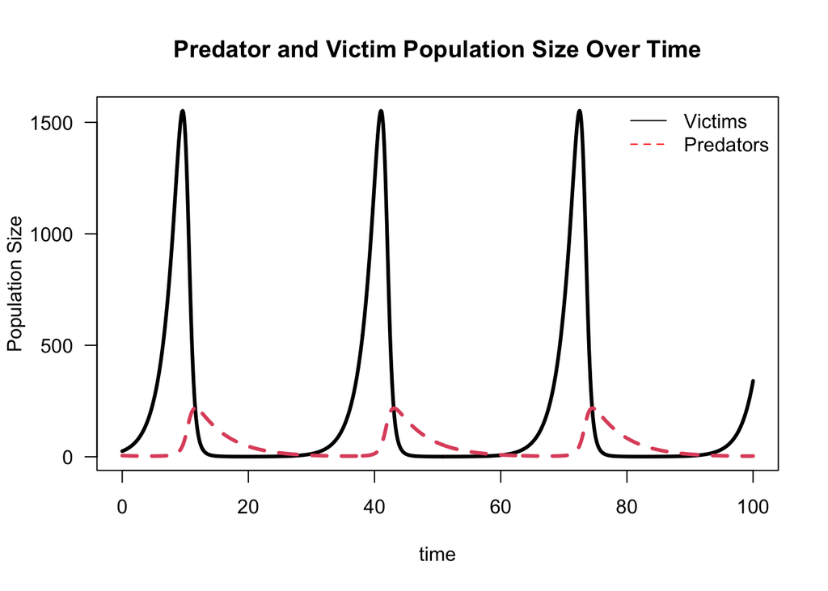

```r
matplot(time, (LV.out[,2:3]), type = 'l', ylab = 'Population Size', lwd = 3, xlab = 'time', las = 1, main='Predator and Victim Population Size Over Time')
legend('topright', col = c('black','red'), lty = c(1,2), legend = c('Victims', 'Predators'), bty = 'n')
```

Question 1 start: Make a plot of the phase plane dynamics. In a phase plane plot, what are the axes? Look at LV.out, how do you turn the data that you have into a plot of the phase plane?

Plot phase plane dynamics

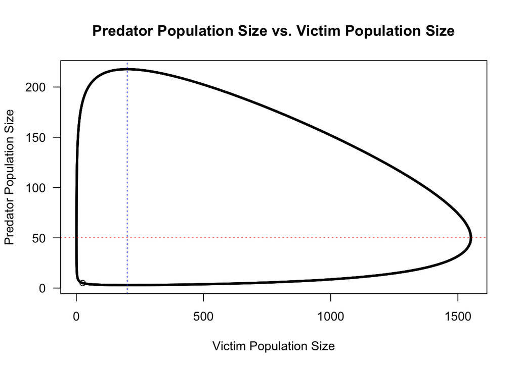

```r
matplot((LV.out[,2]), (LV.out[,3]), type='l', ylab='Predator Population Size', lwd=3, xlab='Victim Population Size', las=1, main='Predator Population Size vs. Victim Population Size')
abline(h=r/a, col='red', lty='dotted')
abline(v=D/(b*a), col='blue', lty='dotted')
points(25, 5)
```

In this phase plane plot, the x axis is the population size of the victims and the y axis is the predator population size. This plot is showing that as the victim population size is growing exponentially, it’s eventually being limited by the predators as the predator population size goes up and the victim population size starts decreasing again (once it crosses the victim isocline). This trend continue until it hits the predator isocline, at which point the predator population size starts dropping dramatically.

Question 2 start: Now let’s try running again with different initial conditions. All parameters are the same, we’re just changing the starting number of predators and victims

```r
LV.out2 <- ode(c(V0 = 500, P0 = 15), time, predpreyLV, params1)
LV.out3 <- ode(c(V0 = 300, P0 = 50), time, predpreyLV, params1)
```

Plot all three phase planes on the same plot, add isoclines and starting conditions.

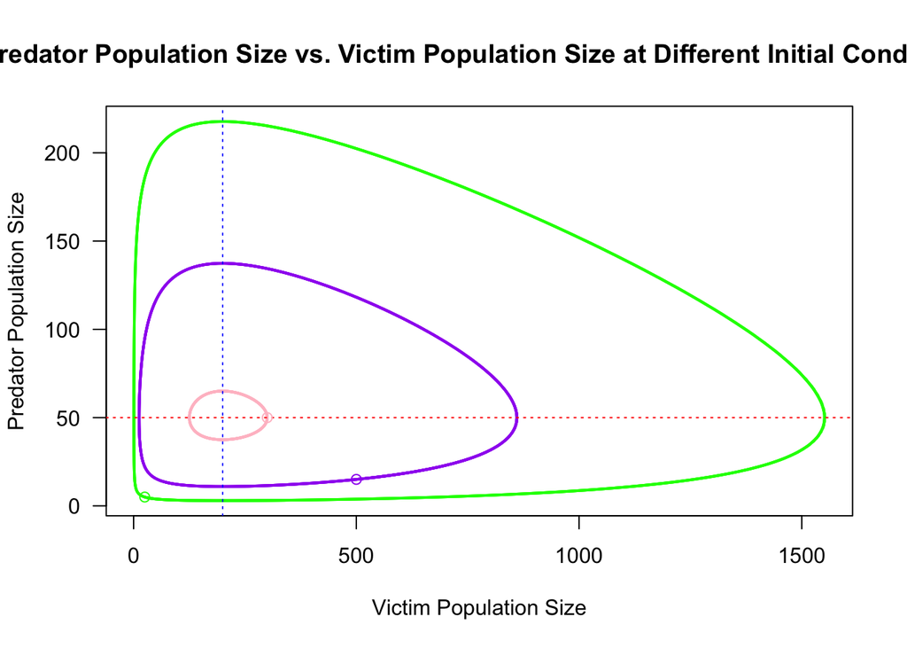

```r
matplot((LV.out[,2]), (LV.out[,3]), type='l', ylab='Predator Population Size', lwd=2, xlab='Victim Population Size', las=1, col='green', main='Predator Population Size vs. Victim Population Size at Different Initial Conditions')
lines(LV.out2[,2], LV.out2[,3], lwd=2, col='purple')
lines(LV.out3[,2], LV.out3[,3], lwd=2, col='pink')
abline(h=r/a, col='red', lty='dotted')
abline(v=D/(b*a), col='blue', lty='dotted')
points(25, 5, col='green')
points(500, 15, col='purple')
points(300, 50, col='pink')
```

Question 3 start: #Now we’re going to plot the dynamics of each population over time for each of the three sets of starting conditions.

Break up graphics windown into 1 row and 3 columns to plot 3 graphs together.

```r
par(mfrow = c(1,3))
#How to undo this setting to go back to just one plotting window
#par(mfrow=c(1,1))
```

Plot n vs t dynamics:

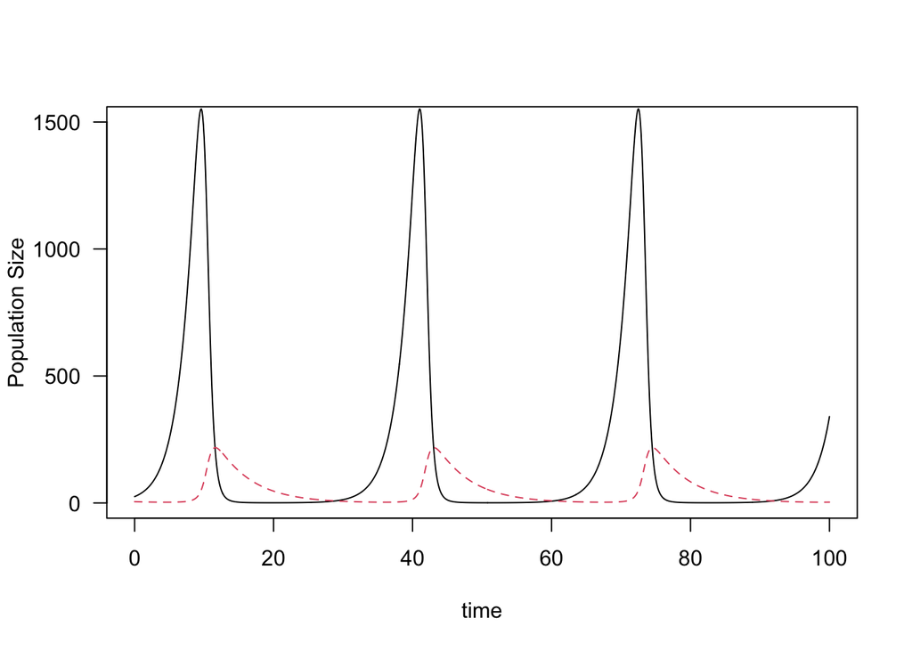

```r
matplot(time, (LV.out[,2:3]), type = 'l', ylab = 'Population Size', lwd = 1, xlab = 'time', las = 1, ylim = c(0,1500))
```

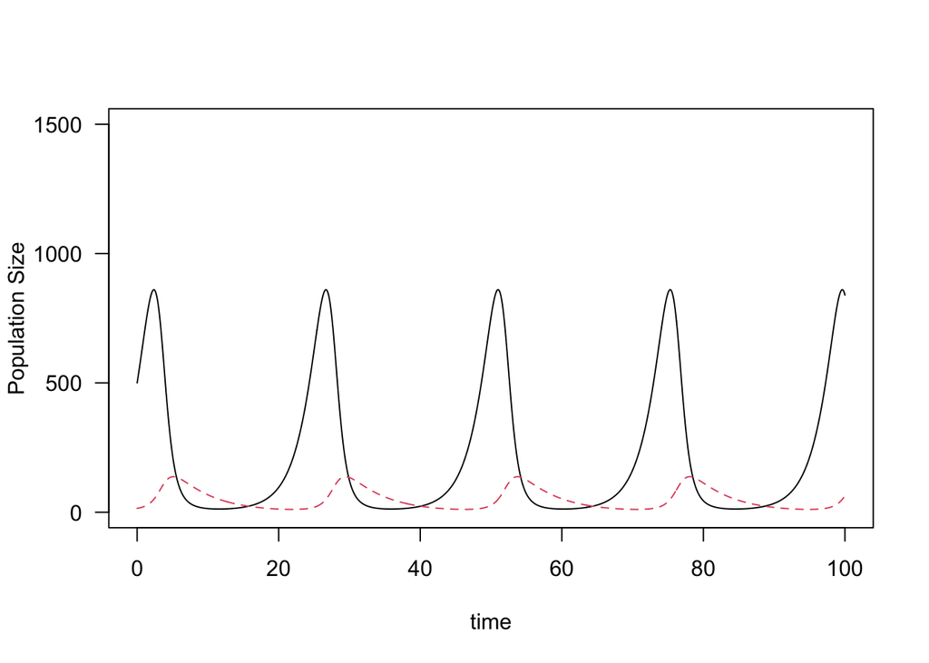

```r
matplot(time, (LV.out2[,2:3]), type = 'l', ylab = 'Population Size', lwd = 1, xlab = 'time', las = 1, ylim=c(0,1500))
```

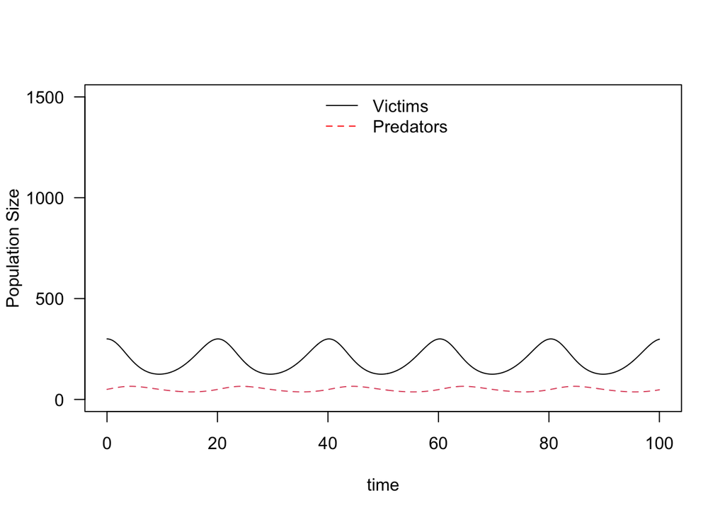

```r
matplot(time, (LV.out3[,2:3]), type = 'l', ylab = 'Population Size', lwd = 1, xlab = 'time', las = 1, ylim=c(0, 1500))

legend('top', col = c('black','red'), lty = c(1,2), legend = c('Victims', 'Predators'), bty = 'n')
```

The amplitude of the cycles correspond to the changes in the population sizes of the victims and the predators depicted in the phase plane plot.

Question 4 start: Everything so far was simple Lotka Volterra, let’s add density dependence to the prey. To do this you need to make a new function, so go up to the Introduction and look at the function predprey.LV.You need to make a new function where you change the dV.dt and dP.dt models to reflect density dependence in the prey. To do this you will need to add a new parameter, K, so we need to set its value and add it to our parameter vector

```r
K = 1000 #set carrying capacity k

#add density dependence to prey
predpreyLVD <- function(t, y, params) {
  V <- y[1] #initial pop of victims
  P <- y[2] #initial pop of predators
  with(as.list(params), {
    dV.dt <- r*V*(1-(V/K)) - a*V*P
    dP.dt <-  b*a*V*P - D*P
    return(list(c(dV.dt, dP.dt)))
  })
}
```

Question 5 start: run the solver. As before, plot the population dynamics over time and the phase plane. You can use segments to draw the prey isocline.

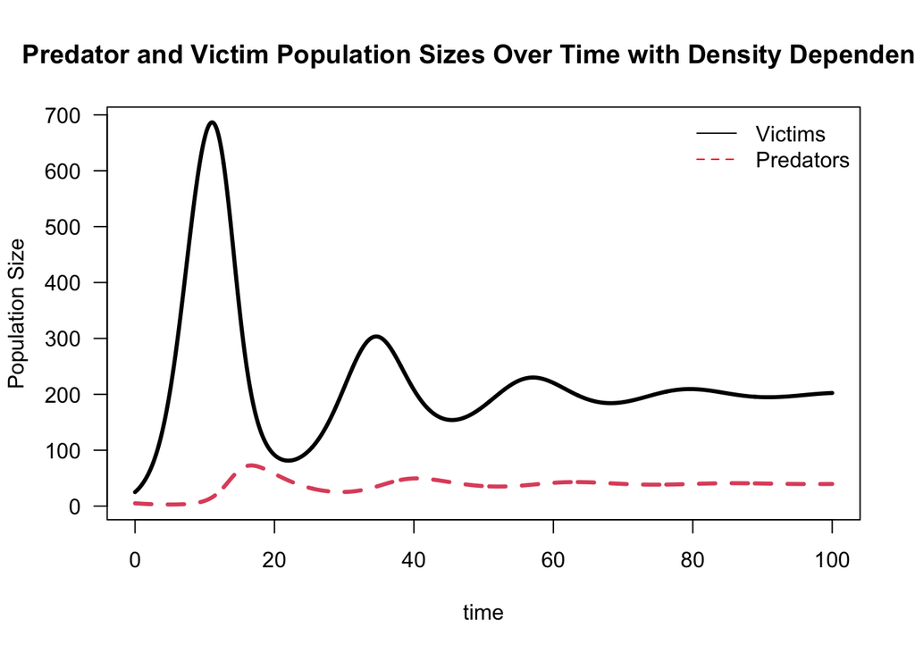

```r
LVD.out <- ode(c(VO = 25, PO = 5), time, predpreyLVD, params1) #run solver

#change back to one plotting window
par(mfrow=c(1,1))

#plot the population dynamics over time for the new function with density dependence included
matplot(time, (LVD.out[,2:3]), type = 'l', ylab = 'Population Size', lwd = 3, xlab = 'time', las = 1, main='Predator and Victim Population Sizes Over Time with Density Dependence')
legend('topright', col = c('black','red'), lty = c(1,2), legend = c('Victims', 'Predators'), bty = 'n')
```

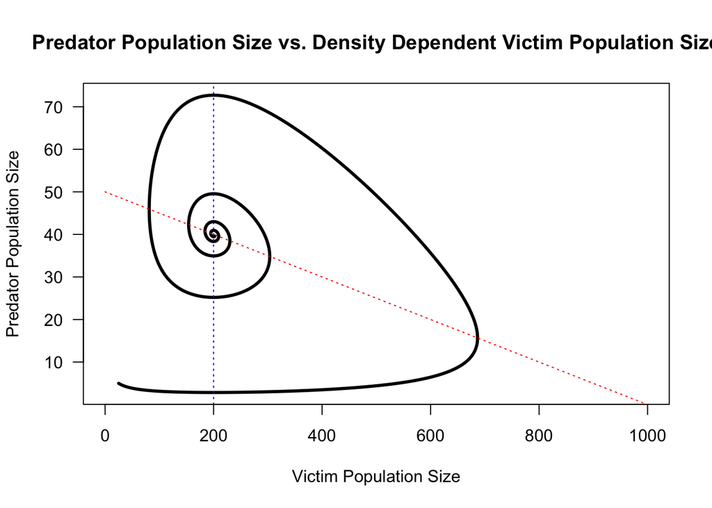

```r
#plot the phase plane + isoclines
matplot((LVD.out[,2]), (LVD.out[,3]), type='l', ylab='Predator Population Size', lwd=3, xlab='Victim Population Size', las=1, xlim = c(0, 1000), main='Predator Population Size vs. Density Dependent Victim Population Size')
abline(v=D/(b*a), col='blue', lty='dotted')

#use segments to draw the prey isocline (from starting point to where it hits carrying capacity)
segments(0, 50, 1000, 0, col = 'red', lty = 'dotted')
```

Question 6 start: Try changing initial conditions (i.e. starting values of prey and predators) and looking at the phase plane dynamics. What happens?

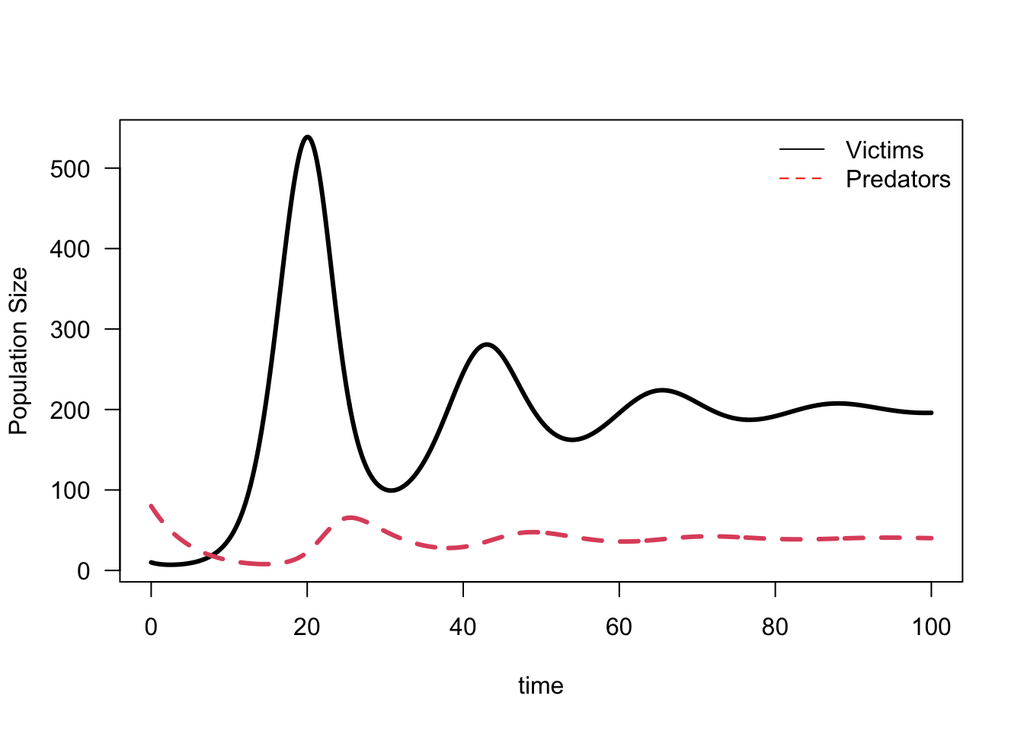

```r
LVD1.out <- ode(c(VO = 10, PO = 80), time, predpreyLVD, params1) #change initial conditions

matplot(time, (LVD1.out[,2:3]), type = 'l', ylab = 'Population Size', lwd = 3, xlab = 'time', las = 1)
legend('topright', col = c('black','red'), lty = c(1,2), legend = c('Victims', 'Predators'), bty = 'n')
```

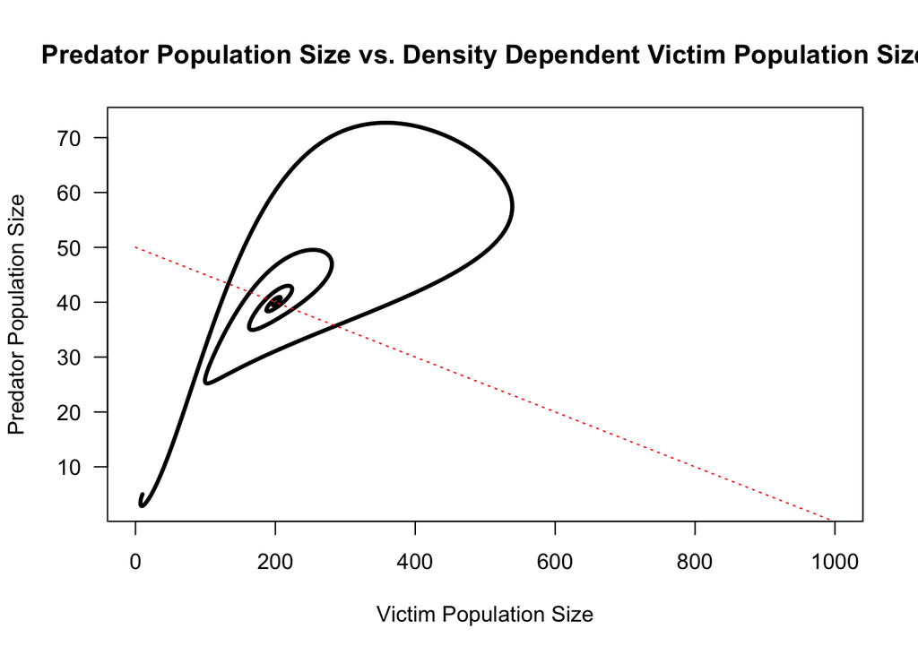

```r
#plot phase plane dynamics
matplot((LVD1.out[,2]), (LVD.out[,3]), type='l', ylab='Predator Population Size', lwd=3, xlab='Victim Population Size', las=1, xlim = c(0, 1000), main='Predator Population Size vs. Density Dependent Victim Population Size')

#victim isocline
segments(0, 50, 1000, 0, col = 'red', lty = 'dotted')
```

#Question 7: Now let’s also add a Type II functional response as well. You will need to refer to the lecture notes and make a new function that incorporates both a Type II functional response by the predators as well as density dependence in the prey (this is the Rozensweig-MacArthur model). Your answer should include your code for the function, plots of N vs t for predators and prey, and plots of the phase plane with the isoclines as well as the population dynamics.

```r
#parameter values

r=0.8
b=0.1
D=0.1
K = 1000
a = 0.005
h = 0.5

#create new function to include Type II functional response and density dependence
predpreyLVII <- function(t, y, params) {
  V <- y[1] #initial pop of victims
  P <- y[2] #initial pop of predators
  with(as.list(params), {
    dV.dt <- (r*V*(1-(V/K))) - (a*V*P)/(1+(a*h*V))
    dP.dt <-  (b*a*V*P)/(1+(a*h*V)) - D*P
    return(list(c(dV.dt, dP.dt)))
  })
}

#make vector of parameters
params1 <- c(r=r, a=a, b=b, D=D)

#set the time sequence, make all values between 0 and 100 in increments of 0.1
time = seq(0, 200, by = 0.1)
#run differential equation solver
LVII.out <- ode(c(VO = 25, PO = 5), time, predpreyLVII, params1)

head(LVII.out)
```

```
##      time       VO       PO
## [1,]  0.0 25.00000 5.000000
## [2,]  0.1 26.96289 4.956289
## [3,]  0.2 29.07603 4.913398
## [4,]  0.3 31.35031 4.871343
## [5,]  0.4 33.79716 4.830138
## [6,]  0.5 36.42874 4.789799
```

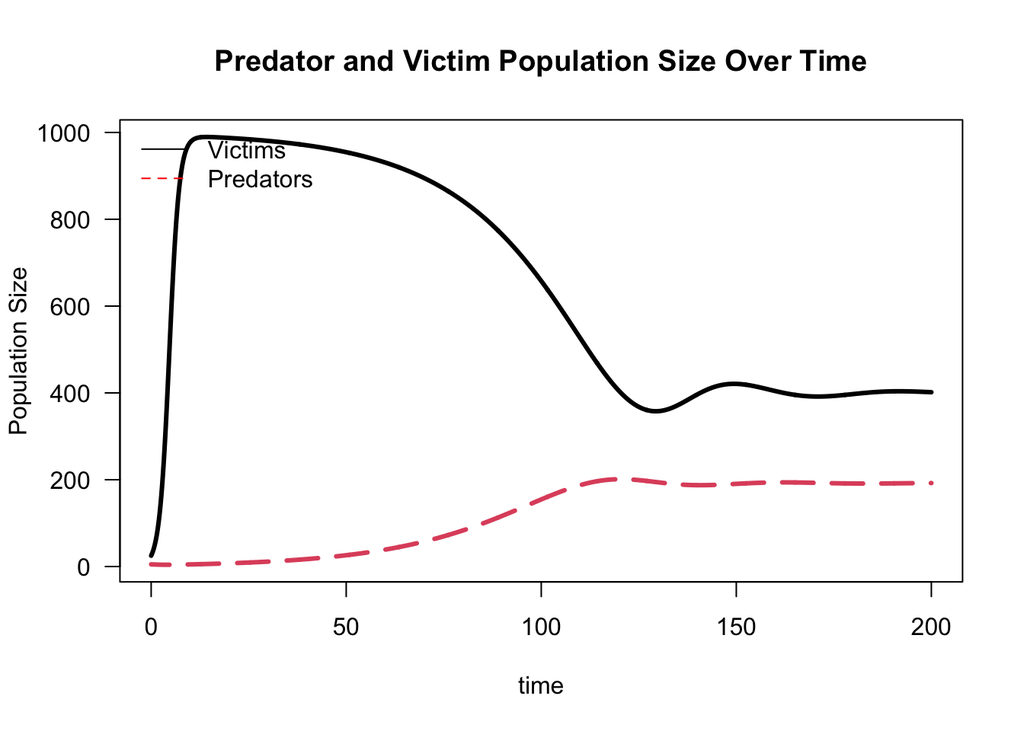

```r
#plot the dynamics of the two populations over time
matplot(time, (LVII.out[,2:3]), type = 'l', ylab = 'Population Size', lwd = 3, xlab = 'time', las = 1, main='Predator and Victim Population Size Over Time')
legend('topleft', col = c('black','red'), lty = c(1,2), legend = c('Victims', 'Predators'), bty = 'n')
```

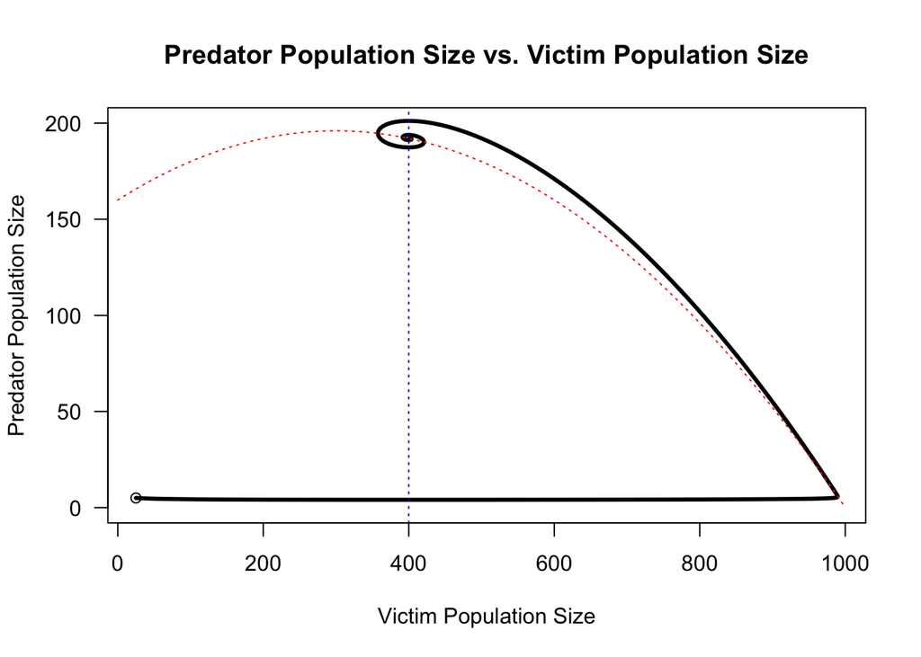

```r
#plot phase plane dynamics
matplot((LVII.out[,2]), (LVII.out[,3]), type='l', ylab='Predator Population Size', lwd=3, xlab='Victim Population Size', las=1, main='Predator Population Size vs. Victim Population Size', ylim=c(0, 200))

#calculate and plot isoclines
curve(r*(1-(x/K))*(1+(a*h*x))/a, from=0, to=1000, add=TRUE, col='red', lty='dotted')
abline(v=D/(b*a-D*h*a), col='blue', lty='dotted')
points(25, 5)
```

Question 8: What happens if you double K? Show N vs. t and phase plane plots of both cases and interpret. Adjust your axis limits so that all of the dynamics can be seen. This is called the Paradox of Enrichment!

```r
k=2000 #set new carrying capacity k

predpreyLVIIK <- function(t, y, params) {
  V <- y[1] #initial pop of victims
  P <- y[2] #initial pop of predators
  with(as.list(params), {
    dV.dt <- (r*V*(1-(V/k))) - ((a*V*P)/(1+(a*h*V)))
    dP.dt <-  ((b*a*V*P)/(1+(a*h*V))) - D*P
    return(list(c(dV.dt, dP.dt)))
  })
}

#run differential equation solver
LVIIK.out <- ode(c(VO = 25, PO = 5), time, predpreyLVIIK, params1)

head(LVIIK.out)
```

```
##      time       VO       PO
## [1,]  0.0 25.00000 5.000000
## [2,]  0.1 26.99090 4.956292
## [3,]  0.2 29.13882 4.913411
## [4,]  0.3 31.45590 4.871373
## [5,]  0.4 33.95502 4.830195
## [6,]  0.5 36.65007 4.789893
```

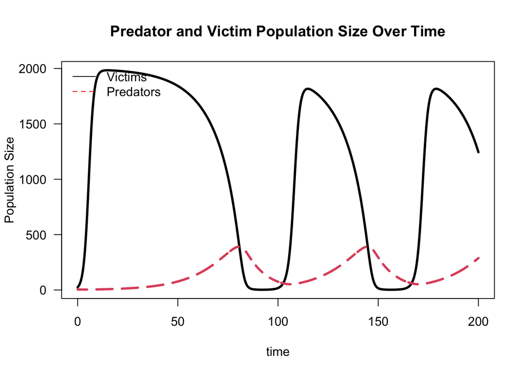

```r
#plot the dynamics of the two populations over time
matplot(time, (LVIIK.out[,2:3]), type = 'l', ylab = 'Population Size', lwd = 3, xlab = 'time', las = 1, main='Predator and Victim Population Size Over Time')
legend('topleft', col = c('black','red'), lty = c(1,2), legend = c('Victims', 'Predators'), bty = 'n')
```

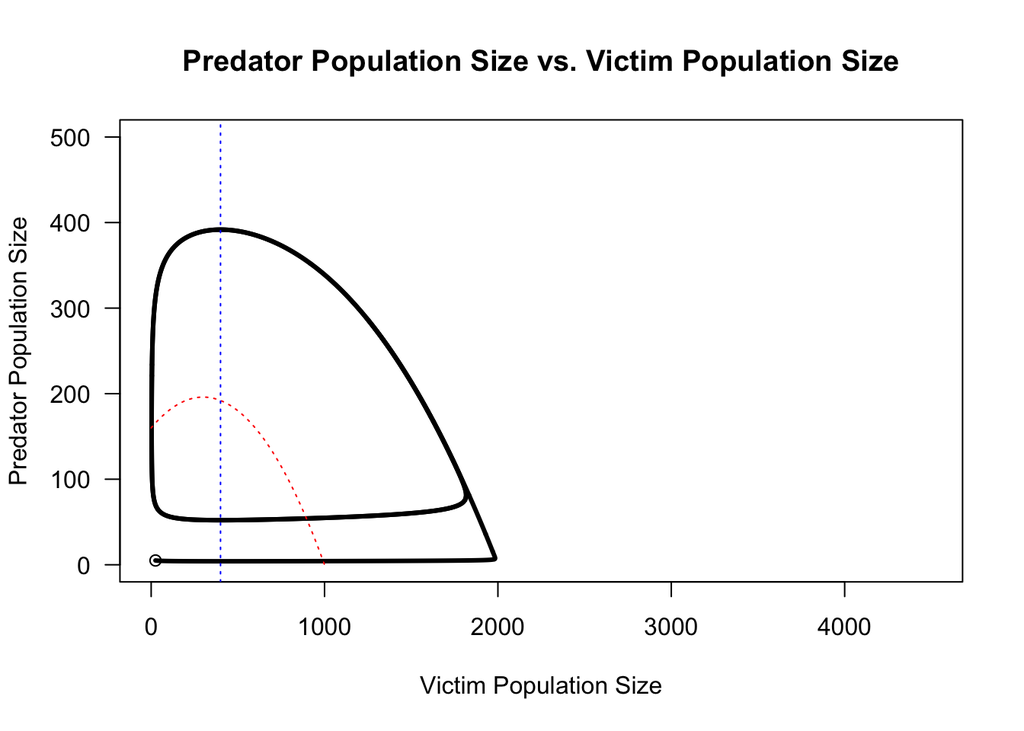

```r
#plot phase plane dynamics
matplot((LVIIK.out[,2]), (LVIIK.out[,3]), type='l', ylab='Predator Population Size', lwd=3, xlab='Victim Population Size', las=1, main='Predator Population Size vs. Victim Population Size', ylim=c(0, 500), xlim = c(0,4500))

#calculate and plot isocline
curve(r*(1-(x/K))*(1+(a*h*x))/a, from=0, to=1000, add=TRUE, col='red', lty='dotted')
abline(v=D/(b*a-D*h*a), col='blue', lty='dotted')
points(25, 5)
```

Question 9: Change the parameter values of your Rosenzweig-MacArthur model from Question 7 to get the predator isocline to fall to the left of the peak of the victim isocline. Explain the changes you make biologically. Plot the dynamics (population over time and phase plane) and compare to the case where the isocline falls to the left of the hump. Your answer will include your code where you changed the parameter values to get the victim isocline to move, and a clear written explanation–more than one or two sentences.

```r
#move vertical isocline (predator)

#parameter values, all same from #7 except for b
r=0.8
b=0.5 #changed from 0.1 to 0.5
D=0.1
K = 1000
a = 0.005
h = 0.5

#same function from question 7
predpreyLVII <- function(t, y, params) {
  V <- y[1] #initial pop of victims
  P <- y[2] #initial pop of predators
  with(as.list(params), {
    dV.dt <- (r*V*(1-(V/K))) - (a*V*P)/(1+(a*h*V))
    dP.dt <-  (b*a*V*P)/(1+(a*h*V)) - D*P
    return(list(c(dV.dt, dP.dt)))
  })
}

#make vector of parameters
params1 <- c(r=r, a=a, b=b, D=D)

#set the time sequence, make all values between 0 and 100 in increments of 0.1
time = seq(0, 200, by = 0.1)
#run differential equation solver
LVII.out <- ode(c(VO = 25, PO = 5), time, predpreyLVII, params1)

head(LVII.out)
```

```
##      time       VO       PO
## [1,]  0.0 25.00000 5.000000
## [2,]  0.1 26.96274 4.980520
## [3,]  0.2 29.07537 4.963333
## [4,]  0.3 31.34867 4.948561
## [5,]  0.4 33.79397 4.936335
## [6,]  0.5 36.42328 4.926794
```

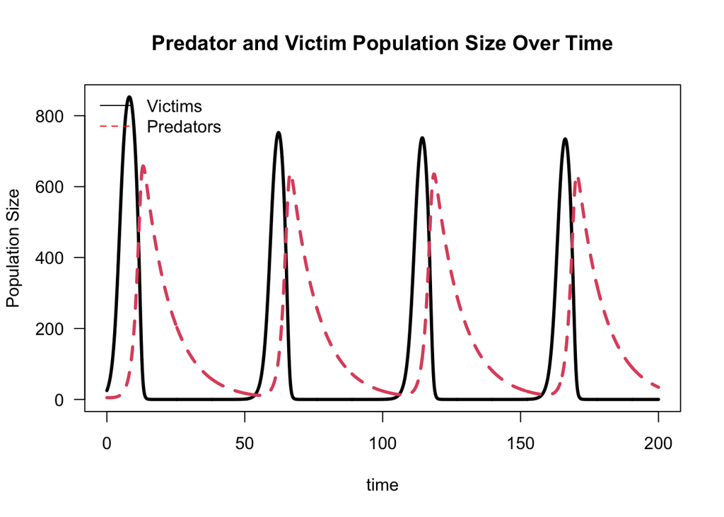

```r
#plot the dynamics of the two populations over time
matplot(time, (LVII.out[,2:3]), type = 'l', ylab = 'Population Size', lwd = 3, xlab = 'time', las = 1, main='Predator and Victim Population Size Over Time')
legend('topleft', col = c('black','red'), lty = c(1,2), legend = c('Victims', 'Predators'), bty = 'n')
```

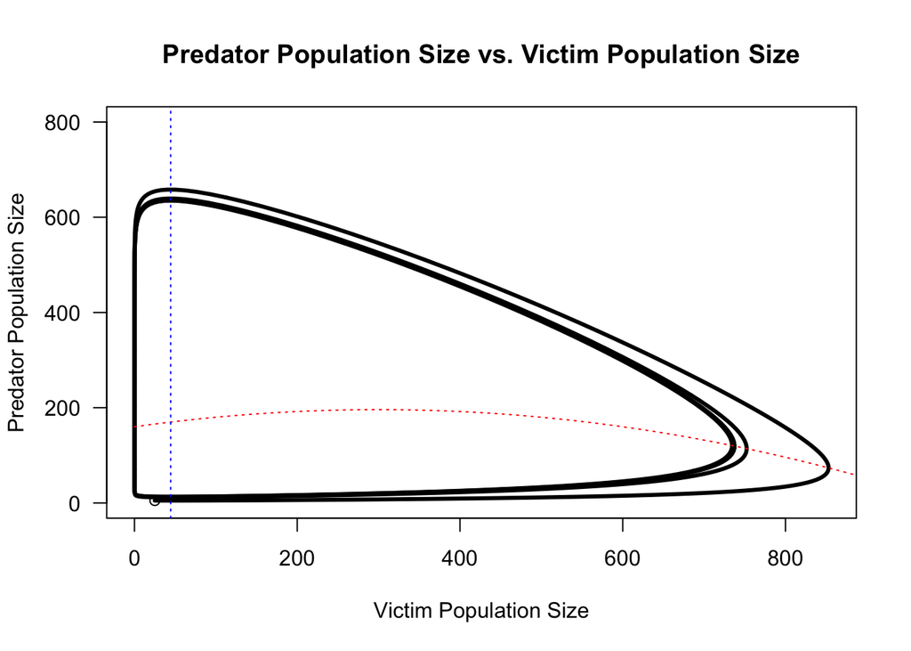

```r
#plot phase plane dynamics
matplot((LVII.out[,2]), (LVII.out[,3]), type='l', ylab='Predator Population Size', lwd=3, xlab='Victim Population Size', las=1, main='Predator Population Size vs. Victim Population Size', ylim=c(0, 800))
curve(r*(1-(x/K))*(1+(a*h*x))/a, from=0, to=1000, add=TRUE, col='red', lty='dotted')
abline(v=D/(b*a-D*h*a), col='blue', lty='dotted')
points(25, 5)
```

To make the predator isocline fall to the left of the peak of the victim isocline, I increased the parameter b, or the conversion efficiency. The conversion efficiency refers to how efficient predators are at converting the prey they consume into new predator offspring. By increasing the conversion efficiency, we saw more oscillations when plotting the dynamics of both populations vs. time compared to the initial parameters. This is therefore more unstabilizing compared to the initial parameters - bigger oscillations could potentially lead to an extinction event occurring. Biologically, you could see this happening with a high enough conversion efficiency rate where the predator is too efficient and ultimately ends up over exploiting its prey, leading to the extinction of both populations.